# 7 Probability distributions

Exploratory data analysis differs from statistics. A statistical model for a measurement involves a description of the random nature of the measurement. To describe randomness, the language of probability is used. Much of this language is implemented in the `Distributions` package of `Julia`, loaded below with other packages:

```julia
using Distributions
using StatsBase, DataFrames
using CairoMakie, AlgebraOfGraphics
```

## 7.1 Probability

This section quickly reviews the basic concepts of probability.

Mathematically a probability is an assignment of numbers to a collection of events (sets) of a probability space. These values may be understood from a model or through long term frequencies. For example, consider the tossing of a *fair* coin. By writing “fair” the assumption is implicitly made that each side (heads or tails) is equally likely to occur on a given toss. That is a mathematical assumption. This can be reaffirmed by tossing the coin *many* times and counting the frequency of a heads occurring. If the coin is fair, the expectation is that heads will occur in about half the tosses.

The mathematical model involves a formalism of sample spaces and events. There are some subtleties due to infinite sets, but we limit our use of events to subsets of finite or countably infinite sets or intervals of the real line. A probability *measure* is a function $P$ which assigns each event $E$ a number with:

- $0 \leq P(E) \leq 1$
- The probability of the empty event is $P(\emptyset) = 0$, the probability of the the sample space is $P(\Omega) = 1$.
- If events $E_1, E_2, \dots$ are *disjoint* then the probability of their *union* is the sum of the individual probabilities.

A *random variable*, $X$, is a function which takes an *outcome* (an element of an event) in a sample space and assigns a number. Random variables naturally generate *events* through sets of the type $\{X = k\}$ for some $k$. This event being *all* outcomes for which $X$ would be $k$. Similarly, $\{X \leq a\}$ for some $a$ describes an event. These are the *typical* events of statistics.

The rules of probability lead to a few well used formulas: $P(X \leq a) = 1 - P(X > a)$ and *for* **discrete** random variables $P(X \leq k) = \sum_{j \leq k} P(X = j)$. Both illustrated in Figure 7.1.

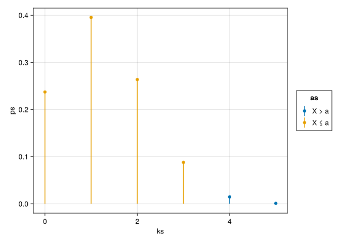

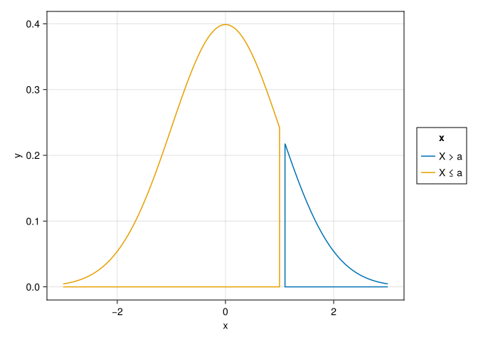

Figure 7.1: Illustrations of $P(X \leq a)$ = $1 - P(X > a)$ for a discrete and continuous distribution.

A *distribution* of a random variable is a description of the probabilities of events generated by a random variable. For our purposes, it is sufficient to describe events of the type $\{X \leq a\}$, $\{X < a\}$, or $\{X = a\}$, others being formed through intersections and unions. A valid description of the *cumulative distribution function*, $F(a) = P(X \leq a)$, (abbreviated cdf) describes the distribution of a random variable.

There are 2 types of distributions where a related function describes the distribution, discrete and continuous distributions.

A **discrete** random variable is one which has $P(X = k) > 0$ for at most a finite or *countably* infinite set of numbers. For example, if $X$ is the number of coin tosses producing heads in $n$ tosses, then the finite $k$s are $0,1,2, \dots, n$. Whereas, if $X$ is the number of coin tosses needed to toss *one* head. The $k$ would be $1, 2, \dots$ (with no upper bound, as one could get extremely unlucky). For *discrete* random variables it is enough to describe $f(k) = P(X=k)$ for the valid $k$s. The function $f(k)$ is called the pdf (probability distribution function). An immediate consequence is $\sum_k f(k) = 1$ and $f(k) \geq 0$.

A **continuous** random variable is described by a function $f(x)$ where $P(X \leq a)$ is given by the *area* under $f(x)$ between $-\infty$ and $a$. The function $f(x)$ is called the pdf (probability density function). An immediate consequence is the *total* area under $f(x)$ is $1$ and $f(x) \geq 0$.

When defined, the pdf is the basic description of the distribution of a random variable. It says what is *possible* and *how likely* possible things are. For the two cases above, this is done differently. In the discrete case, the possible values are all $k$ where $f(k) =P(X=k) > 0$, but not all values are equally likely unless $f(k)$ is a constant. For the continuous case there are **no** values with $P(X=k) > 0$, as probabilities are assigned to area, and the corresponding area to this event, for any $k$, is $0$. Rather, values can only appear in intervals with positive area ($f(x) > 0$ within this interval) and for equal-length intervals, those with more area above them are more likely to contain values.

A data set in statistics, $x_1, x_2, \dots, x_n$, is typically modeled by a collection of random variables, $X_1, X_2, \dots, X_n$. That is, the random variables describe the *possible* values that can be collected, the values ($x_1, x_2,\dots$) describe the actual values that were collected. Put differently, random variables describe what can happen *before* a measurement, the values are the result of the measurement.

The *joint* cumulative distribution is the probability $P(X_1 \leq a_1, X_2 \leq a_2, \dots X_n \leq a_n)$. A common assumption made for statistics is that each of the random variables is

- *identically distributed*, meaning $F(a) = P(X_i \leq a) = P(X_j \leq a)$ for each pair $(i,j)$.
- *independent*, which means that knowing the value of $X_i$ does not effect the probabilities regarding values for $X_j$, $j \neq i$. (If you know a first toss of a fair coin is heads, it doesn’t change the odds that the second toss will be heads.)

With these two assumptions, the random variables $X_1, X_2, \cdots, X_n$ are termed an *iid* *random sample*. For an iid random sample, this simplification applies: $P(X_1 \leq a_1, X_2 \leq a_2, \dots X_n \leq a_n)=F(a_1)\cdot F(a_2) \cdots F(a_n)$ (independence means “multiply”).

In general, the distribution of a random variable may be hard to describe. For example, suppose the random variable is the sample median, $M$, of $X_1, X_2, \cdots, X_n$. With the assumption of an iid random sample, a formula for the *distribution* of $M$ can be worked out in terms of the underlying pdf, $f$ and cdf, $F$. But without that assumption, it becomes intractable, in general.

When a distribution can not be fully identified, it can still be described. A few basic summaries of a probability distribution are:

- The *mean* or average value. For a discrete distribution this is $\sum_k k P(X=k)$, which is a *weighted* average of the possible values, weighted by how likely they are. For a continuous distribution, a similar formula using calculus concepts applies. Both can be viewed from a center of mass perspective. The symbol $\mu$ or $E(X)$ (expectation) is used to represent the mean.[^1]
- The *variance* of a probability distribution describes the spread; the *standard deviation* is the square root of the variance. For a random variable, the variance is described by the *average value* of the centered random variable, squared: $E( (X - \mu)^2 )$. The symbol $\sigma^2$ is used to represent the variance, $\sigma$ then is the standard deviation. $VAR(X)$ is also used to represent the variance of a random variable, similarly $SD(X)$ is used for the standard deviation.

The transformation $X - \mu = X - E(X)$ centers the random variable $X$, so that $E(X-\mu) = 0$.

The transformation $Z = (X - \mu)/\sigma$, following the $z$-score, centers and *scales* the random variable $X$. The random variable $Z$ has $E(Z) = 0$ and $VAR(Z) = 1$.

For a *random sample* $X_1, X_2, \dots, X_n$ the sum $S = \sum_k X_k$ has the property that $E(S) = \sum_k E(X_k)$ (“expectations add”). This is true even if the sample is not iid. For example, finding the average number of heads in $100$ tosses of a fair coin is easy, it being $100 \cdot (1/2) = 50$, the $1/2$ being the expectation of a single heads where $X_i=1$ if heads, and $X_i=0$ if tails.

While $E(X_1 + X_2) = E(X_1) + E(X_2)$, as expectations are *linear* and satisfy $E(aX+bY) = aE(X)+bE(Y)$, it is not the case that $E(X_1 \cdot X_2) = E(X_1) \cdot E(X_2)$ in general—though it is true when the two random variables are independent. As such, the variance of $S= \sum_k X_k$ is:

$$VAR(\sum_k X_k) = \sum_k VAR(X_k) + 2 \sum_{i < j} COV(X_i, X_j),$$

where the *covariance* is $COV(X_i,X_j) = E((X_i - E(X_i)) \cdot (X_j - E(X_j)))$. If, the random variables in the sample are independent, then the covariances are $0$ and the variance of a sum is the sum of the variances.

### 7.1.1 Statistical language

In statistics we have seen a random sample is a sequence of random variables $X_1, X_2, \dots, X_n$. Assume this is an iid random sample.

The *population* is the common distribution of each random variable in the random sample. Populations have a pdf and cdf, often denoted $f_X(x)$ and $F_X(x)$. Populations are summarized by *parameters*, such as the mean ($\mu$) or the standard deviation ($\sigma$).

A statistic is some summary of a random sample. For example, the median, or middle value, or the sample mean $\bar{X} = (X_1 + X_2 + \cdots X_n)/n$. Statistics are also *random variables* and so are described by a distribution (when computable) or summarized by values such as the mean or standard deviation.

For the sample mean from an iid random sample, the above says:

$$\begin{align*}
E(\bar{X}) &= E\left(\frac{X_1 + X_2 + \cdots + X_n}{n}\right) \\
&= \frac{1}{n} \sum_k E(X_k) \\
&= \frac{1}{n} \sum_k \mu = \mu;\\
VAR(\bar{X}) &= \frac{1}{n^2} \cdot \left(\sum_k VAR(X_k) + 2\sum_{i < j} COV(X_i,X_j)\right)\\
&= \frac{1}{n^2}\sum_k VAR(X_k) \\
&= \frac{1}{n^2} n \cdot \sigma^2 = \frac{\sigma^2}{n}.
\end{align*}$$

The standard deviation then is $SD(\bar{X}) = \sigma/\sqrt{n}$.

In short, the expected value of the mean is the expected value of the *population*; the variance of the mean (of an iid random sample) is the variance of the population *divided* by the sample size, $n$. The latter speaks to variability: there is more variability in a single random value than in an average of the random values. The distribution of $\bar{X}$ can be expressed through formulas in terms of $f_X(x)$, but is *well approximated* as $n$ gets large by a distribution characterized by its mean and standard deviation, as will be seen.

There are parallels between random variables and data sets:

- The random sample $X_1, X_2, \dots, X_n$ is realized in a data set by values $x_1, x_2, ... x_n$.
- The distribution, $f_X(x)$, is reflected in the data set.
- The distribution, $f_X(x)$ is *typically* described by key *parameters*
- The data set is *typically* summarized by sample statistics.

Statistical inference makes statements using the language of probability about the *parameters* in terms of various sample statistics.

An intuitive example is the tossing of a fair coin modeling heads by a $1$ and tails by a $0$ then we can *parameterize* the distribution by $f(1) = P(X=1) = p$ and $f(0) = P(X=0) = 1 - P(X=1) = 1-p$. This distribution is summarized by $\mu=p$, $\sigma = \sqrt{p(1-p)}$. A *fair* coin would have $p=1/2$. A sequence of coin tosses, say H,T,T,H,H might be modeled by a sequence of iid random variables, each having this distribution. Then we might expect a few things, where $\hat{p}$ below is the proportion of heads in the $n$ tosses:

- A given data set is not random, but it may be viewed as the result of a random process and had that process been run again would likely result in a different outcome. These different outcomes may be described probabilistically in terms of a distribution.
- If $n$ is large enough, the sample proportion $\hat{p}$ should be *close* to the population proportion $p$.
- Were the sampling repeated, the variation in the values of $\hat{p}$ should be smaller for larger sample sizes, $n$.

These imprecise statements can be made more precise, as will be seen. Figure Figure 7.2 illustrates a population, several different samples from it with the *sample means* visualized by a density plot. The density plot is centered at the same location as the population, but is narrower, reflecting smaller variability.

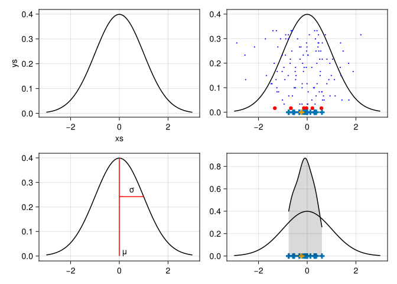

Figure 7.2: The top-left figure shows a population, the lower left parameters associated with the population. The top-right shows one sample from the population in red, other possible samples in blue with sample means summarized in the bottom most row. A density estimate of these sample means appears in the lower-right figure showing how it is centered on the population, but more concentrated. Inference uses the language of probability to characterize a population parameter based on a single random sample.

Inferential statistics is similar: A population is a distribution summarized by parameters. A random sample drawn from a population is summarized by statistics. A statistic summarizes just one sample, but the language of probability is used to infer from that one sample, statements about the parameters which would be apparent were there many different random samples.

## 7.2 The Distributions package

While populations are in general described by a cdf, populations which are discrete or continuous are more naturally described by their pdf. There are many standard pdfs used to describe different types of randomness and supported in the `Distributions` package. This section reviews several.

```julia
using Distributions
```

### 7.2.1 Bernoulli, Binomial, Geometric

The simplest non-trivial distribution is that used to model a coin toss: $P(X=1)=p$ and $P(X=0) = 1-p$. We see this is *parameterized* by $p$, the probability of heads (say). This also happens to be the mean of this distribution. By the rules of probability, we must have $0 \leq p \leq 1$.

In the `Distributions` package, named distributions are given a type, in this case `Bernoulli` which requires a value of $p$ to be formed. The following code uses the type and confirms the mean of this distribution is indeed $p$:

```julia
p = 0.25
Be = Bernoulli(p)
mean(Be)
```

```
0.25
```

The `Bernoulli(p)` distribution is very simple, but combinations of $Bernoulli(p)$ random variables give rise to many interesting distributions. For example, the number of heads in 10 coin tosses could be modeled by the sum of 10 Bernoulli random variables. The distribution of this random variable is described by the `Binomial` distribution. It has two parameters: $p$ for the Bernoulli $10$ for the number of tosses and is implemented with the `Binomial(n,p)` type. There are several summary statistics for the types supported by `Distributions`, including: `mean`, `median`, `std`:

```julia
n, p = 10, 1/2
B = Binomial(n, p)
mean(B),  median(B), std(B)
```

```
(5.0, 5, 1.5811388300841898)
```

The mean and standard deviation for the Binomial can be easily computed when this statistic is viewed as a sample mean of 10 Bernoulli random variables ($np$ and $\sqrt{np(1-p)}$).

More is known. For example, the value of this random variable can only be between 0 and 10. The `extrema` function combines both the `minimum` and `maximum` functions to give this:

```julia
extrema(B)
```

```
(0, 10)
```

The `insupport` function is similar, returning `true` or `false` if a value, `x`, is in the support of the distribution, that is if `x` is a *possible* value:

```julia
insupport(B, 5), insupport(B, 15), insupport(B, 5.5)
```

```
(true, false, false)
```

We see only `5` is a possible value. Its probability, $P(X=5)$ for this discrete distribution, is computed by `pdf`:

```julia
pdf(B, 5)
```

```
0.24609375000000022
```

Figure 7.3 shows different examples of the binomial distribution. When both $np$ and $n(1-p)$ are $5$ or more, the shape is roughly symmetric.

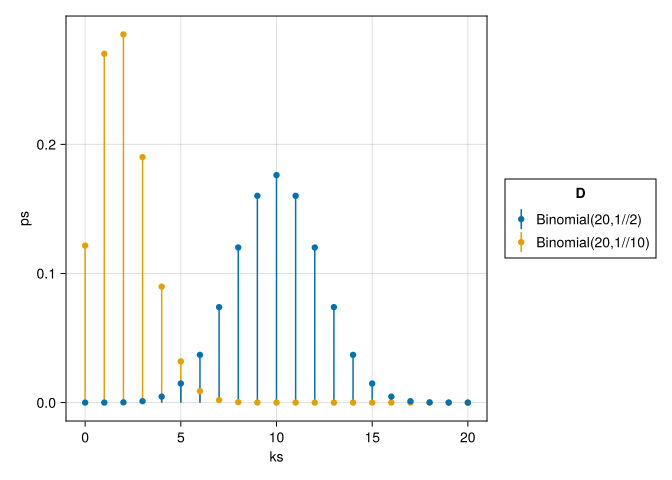

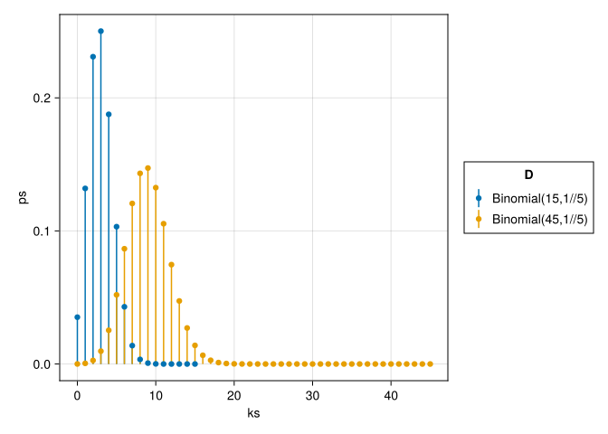

Figure 7.3: The binomial distribution for different $n$ and $p$ values. The left graphic fixes $n=20$ and shows different $p$ values. One is more “bell-shaped” as both $np$ and $n(1-p)$ are bigger than $5$. The right graphic shows a fixed $p$ and different $n$s. As $n$ gets bigger, the shape is more bell shaped.

The cumulative distribution function is computed by `cdf` with the same calling style, `cdf(D, x)`. The complementary cumulative distribution function, `1 - F(x)`, is computed by `ccdf(D, x)`.

The cumulative distribution, $F(a)$, finds the value $p$ for a given value of $a$ in $p = P(X \leq a)$. It’s inverse operation, finding a value $a$ in $p=P(X \leq a)$ for a given $p$, is returned by `quantile`.[^2] Quantiles are computed with the calling style `quantile(D, p)`.

A related question is the number of coin tosses needed to get the *first* heads. If $X$ is this distribution, the the event $\{X > k\}$ can be described as the first $k$ tosses were tails. This probability is directly computable. The distribution of this number depends only on the parameter $p$ and is called the *Geometric distribution*.

For example, we can see here the mean, and standard deviation, and also that the the number is unbounded:

```julia
p = 1/2
G = Geometric(p)
mean(G), std(G), extrema(G) # 1/p, 1/√p, 0,1,...,∞
```

```
(1.0, 1.4142135623730951, (0, Inf))
```

### 7.2.2 Uniform and DiscreteNonParametric distributions

A *discrete* uniform random variable on $a, a+1, \dots, b$ assigns equal weight to each value. Hence, each possible value is equally likely. The `DiscreteUniform(a,b)` type models this distribution. For example, to model the roll of a 6-sided die, we might have:

```julia
D = DiscreteUniform(1,6)
mean(D), std(D)
```

```
(3.5, 1.707825127659933)
```

More generally, a distribution which assigns weight $p_k$ to values $x_1, x_2, \dots, x_n$ is modeled by the `DiscreteNonParametric(xs, ps)` distribution. For example, Benford’s “law” is an observation that the first non-zero digit of many data sets follows a certain pattern. For this the *possible* values are $1$ through $9$ and their probabilities are $f(k) = P(X=k) = \log_{10}(k+1) - \log_{10}(k)$. We can model this with:

```julia
xs = 1:9
ps = log10.(xs .+ 1) - log10.(xs)
B = DiscreteNonParametric(xs, ps)
```

```
Distributions.DiscreteNonParametric{Int64, Float64, UnitRange{Int64}, Vector{Float64}}(
support: 1:9
p: [0.3010299956639812, 0.17609125905568124, 0.12493873660829996, 0.09691001300805646, 0.07918124604762478, 0.06694678963061318, 0.057991946977686726, 0.05115252244738133, 0.04575749056067513]
)
```

We can answer questions like the mean, the standard deviation, and what is the probability the number is `5` or less with:

```julia
mean(B), std(B), cdf(B, 5)
```

```
(3.4402369671232065, 2.4609982997506656, 0.7781512503836436)
```

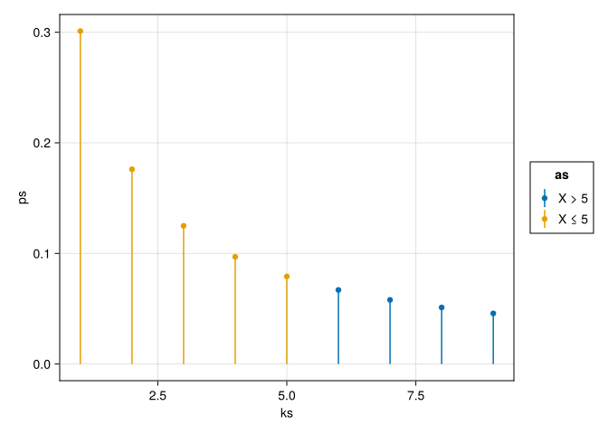

Figure 7.4: Benford’s law illustrated with values $5$ or less illustrated

```julia
a = 5

ks = support(B)
ps = pdf.(B, ks)
as = ifelse.(ks .<= a, "X ≤ $a", "X > $a")

layers = visual(Rangebars) + visual(Scatter)
p = data((; ks, ps, as)) * layers * mapping(:ks, :ps, :ps => zero, color=:as)

draw(p)
```

In `Distributions` the `Categorical` type can also have been used to construct this distribution, it being a special case of `DiscreteNonParametric` with the `xs` being $1, \dots, k$.

The multinomial distribution is the distribution of counts for a sequence of $n$ iid random variables from a `Categorical` distribution. This generalizes the binomial distribution. Let $X_i$ be the number of type $i$ in $n$ samples. Then $X_1 + X_2 + \cdots + X_k = n$, so these are not independent. They have mean $E(X_i)=np_i$, variance $VAR(X_i) = np_i (1-p_i)$, like the binomial, but covariance $COV(X_i, X_j) = -np_i p_j, i \neq j$. (Negative, as large values for $X_i$ correlate with smaller values for $X_j$ when $i \neq j$.)

### 7.2.3 The continuous uniform distribution

The continuous uniform distribution models equally likely outcomes over an interval $[a,b]$. (The endpoints possibly open, as mathematically they have no chance of being selected.) For example, the built-in `rand` function for Float64 values returns random numbers which are modeled by being uniform over $[0,1)$. (That they can be `0` but not `1` is a reality of how computers and mathematical models aren’t always exactly the same, but rather the model is an abstraction of the implementation.)

The `Uniform(a,b)` type models these numbers. Here we see `rand` being used to randomly sample $3$ uniform numbers using a more general interface than the use of `rand` in base `Julia`:

```julia
U = Uniform(0, 1)
rand(U, 3)
```

```
3-element Vector{Float64}:
 0.8018506783367227
 0.30829210401704465
 0.6217903796471167
```

If $U$ is Uniform on $[0,1]$ then $Y = aU + b$ is uniform on $[b, b+a]$. The difference in means is shifted by $b + E(U)$, the difference in standard deviations is scaled by $a$. We can do the algebra of linear transformations using overloaded operations:

```julia
a, b = 2, 3
Y = a * U + b
q1 = mean(U) == mean(Y) - (b + mean(U)) == (1 + 0)/2
q2 = std(U) == std(Y)/a  == sqrt(1/12)
q1, q2
```

```
(true, true)
```

### 7.2.4 The normal distribution

The most important distribution in statistics is called the normal distribution. This is a bell-shaped distribution completely described by its mean and standard deviation, `Normal(mu, sigma)` (though some math books use the variance, $\sigma^2$ for the second parameter). The *standard* normal has $\mu=0$ and $\sigma=1$. Standard normal random variables are generically denoted by $Z$:

```julia
Z = Normal(0, 1)
mean(Z), std(Z)
```

```
(0.0, 1.0)
```

There are many facts about standard normals that are useful to know. First we have the three rules of thumb—$68$, $95$, $99.7$—describing the amount of area above $[-1,1]$, $[-2,2]$, and $[-3,3]$. We can see these from the `cdf` with:

```julia
between(Z, a, b) = cdf(Z,b) - cdf(Z,a)
between(Z, -1, 1), between(Z, -2, 2), between(Z, -3, 3)
```

```
(0.6826894921370861, 0.9544997361036416, 0.9973002039367398)
```

These values are important as the $z$ scores of different data sets are often assumed to be normal or approximately normal, so, for example, about 95% of such a data set should have $z$ scores within $-2$ and $2$.

The transformation $Y = \mu + \sigma \cdot Z$ will produce a normal with mean $\mu$ and standard deviation $\sigma$, modeled more directly by `Normal(mu, sigma)`.

A common question in introductory statistics is what values $a$ and $b$ correspond to $(1-\alpha)\cdot 100$% of the area under the pdf of $Y$? There are infinitely many such answers, but only one pair that is symmetric about the mean, $\mu$. This can be found with the help of `quantile` *and* the observation that *since* the pdf of $Y$ is symmetric, there will be area $1 - \alpha$ **plus** $\alpha/2$ to the left of $b$, a question tailor-made for `quantile`. From $b$, $a$ can be found from symmetry, it being equidistant from the mean as $b$ is.

For example:

```julia
alpha = 0.05
mu, sigma = 10, 20
Y = Normal(mu, sigma)
b = quantile(Y, 1 - alpha + alpha/2)
a = mu - (b - mu)
a, b, between(Y, a, b)
```

```
(-29.19927969080115, 49.19927969080115, 0.9500000000000004)
```

An observation of De Moivre in 1733 about the binomial proved foundational. Suppose we consider the binomial distribution with $n$ and $p$ such that $np$ and $n\cdot(1-p)$ are both $10$ or more. Then $\mu = np$ and $\sigma = \sqrt{np(1-p)}$. The cdf of this distribution was observed to be *very* well approximated by the cdf of the $Normal(\mu, \sigma)$ distribution. Furthermore, *asymptotically* they are equal.

For example, the following searches for the largest discrepancy in the cdfs:

```julia
n, p = 100, 1/3
mu, sigma = n*p, sqrt(n*p*(1-p))
B, Y = Binomial(n,p), Normal(mu, sigma)
ks = 0:100
findmax(abs(cdf(B, k) - cdf(Y, k)) for k in ks)
```

```
(0.046989293624614625, 34)
```

This shows an error of not more than $0.0469...$ in approximating the binomial with the normal. The *continuity correction* adjusts for the discrete nature of the binomial by comparing $k$ to $k+1/2$ for the normal. The following is more accurate, as can be seen:

```julia
findmax(abs(cdf(B, k) - cdf(Y, k+1/2)) for k in ks)
```

```
(0.004701503073942237, 34)
```

Of course, computationally it is often just as easy to call `cdf(B, k)` as it is to call `cdf(Y, k + 1/2)`, so the advantage here is theoretical for computationally tractable values of $n$ and $k$. This particular approximation is generalized in the central limit theorem.

### 7.2.5 The Chi-squared distribution

Let $Z$ be a standard normal random variable. As seen, a linear transform of $Z$: $Y=\sigma Z + \mu$ will have distribution of $Normal(\mu,\sigma)$, a different transform $Y=Z^2$ can have its distribution computed using some tricks, e.g. ($P(Z^2 < a) = P(-\sqrt{a} < Z < \sqrt{a})$.) If we have an iid random sample, $Z_1, Z_2, \dots, Z_n$ the distribution of $\chi^2 = Z_1^2 + Z_2^2 + \cdots + Z_n^2$ is of interest. (It may be viewed as the distance squared of a randomly chosen point in space, say.) The distribution of $\chi^2$ is the *Chi-squared distribution* with $n$ degrees of freedom and is implemented in the `Chisq(n)` type.

### 7.2.6 The T and F distributions

There are two main distributions which arise in the distribution of many sample statistics related to the linear regression model, these are the $T$-distribution of Student and the $F$-distribution of Fischer. Both are *parameterized* by “degrees of freedom,” which are more naturally discussed with sampling distributions.

Consider two *independent* random variables, a standard normal $Z$ and a Chi-squared random variable, $Y$, with $\nu$ degrees of freedom. The $T$-distribution with $\nu$ degrees of freedom is the distribution of the ratio:

$$T = \frac{Z}{\sqrt{Y/\nu}}.$$

```julia
T5 = TDist(5)
maximum(abs, rand(T5, 100)), maximum(abs, rand(Z, 100))
```

```
(3.2644950487014412, 3.6559357353003876)
```

Figure 7.5 shows a quantile-normal plot of $T(3)$ in the lower-left graphic. The long tails cause deviations in the pattern of points from a straight line.

The `skewness` method measures asymmetry. For both the $T$ and the normal distributions—both bell shaped—this is $0$. The `kurtosis` function measures *excess kurtosis* a measure of the size of the tails *as compared* to the normal. We can see:

```julia
skewness(T5), skewness(Z), kurtosis(T5), kurtosis(Z)
```

```
(0.0, 0.0, 6.0, 0.0)
```

A distribution with excess kurtosis exceeding the normal is called *leptokurtic*. Such distributions more frequently produce values with $z$ scores larger than expected by the standard normal distribution. A *platykurtic* distribution, on the other hand, would have in more frequently fewer values in the tails and fewer values close to the mean of a standard normal. The uniform distribution is a good example of a playtkurtic distribution, both conditions have a test in `Distributions`:

```julia
isleptokurtic(T5), isplatykurtic(U)
```

```
(true, true)
```

For the $T$-distribution, when the degrees of freedom gets large, say bigger than $100$, the distribution is well approximated by the normal. In the following code, we see a similar comparison as above to compare the difference. For a quantile-normal plot see the upper-right graphic in Figure 7.5.

```julia
T100 = TDist(100)
xs = range(-3, 3, length=100)
findmax(abs(cdf(T100, x) - cdf(Z, x)) for x in xs)
```

```
(0.0015794482887208222, 25)
```

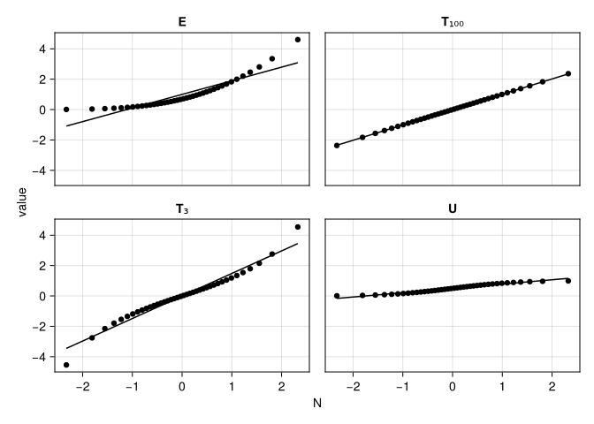

Figure 7.5: Quantile-normal plots for different distributions—$T_3$ is leptokurtic; $T_{100}$ is approximately normal; $U$ is platykurtic; and $E$ is skewed.

Consider now two, independent Chi-squared random variables $Y_1$ and $Y_2$ with $\nu_1$ and $\nu_2$ degrees of freedom. The ratio

$$F = \frac{Y_1/\nu_1}{Y_2/\nu_2},$$

has a known distribution called the $F$-distribution with $\nu_1$ and $\nu_2$ degrees of freedom.

This distribution has different shapes for different parameter values (Figure 7.6), with the distributions becoming more normal as the two parameters get large.

```julia
kurtosis(FDist(5, 10)), kurtosis(FDist(5,100)), kurtosis(FDist(100,100))
```

```
(50.86153846153846, 3.1474470779483217, 0.7278883188966445)
```

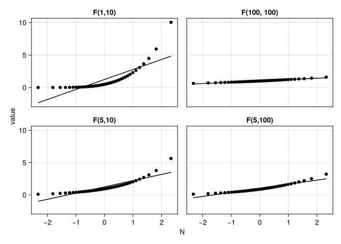

Figure 7.6: Quantile-normal plots of the $F$ distribution for different degrees of freedom. As the degrees of freedom values get bigger, the distribution is more normal.

## 7.3 Sampling distributions

The normal distribution, $T$ distribution, and $F$ distribution are important in statistics as they arise as sampling distributions of certain statistics.

### 7.3.1 The sample mean

For an iid random sample, from a population with mean $\mu$ and standard deviation $\sigma$ we have seen that the sample mean, $\bar{X} = (X_1 + \dots + X_n)/n$ is described by having mean $\mu_{\bar{X}} = \mu$ and standard deviation $\sigma_{\bar{X}} = \sigma / \sqrt{n}$.

What about the distribution itself? This depends on the underlying population.

If the underlying population is *normal*, then $\bar{X}$ is normal. This is true as the sum of two independent normal random variables is normally distributed. That is $\bar{X}$ is bell shaped, centered at the same place as the distribution of any of the $X_i$s but has a *narrower* shape, as the standard deviation is smaller by a factor of $1/\sqrt{n}$.

#### Central limit theorem

De Moivre’s observation that the binomial distribution is asymptotically normal is even more general: the *central limit theorem* informs us that for large enough $n$ the following is true under assumptions::

$$P(\frac{\bar{X} - \mu}{\sigma/\sqrt{n}} \leq z) \approx P(Z \leq z),$$

where $Z$ is a standard normal random variable. That is centering $\bar{X}$ by *its* mean and then scaling by its standard deviation results in a random variable that is approximately a standard normal if $n$ is large enough.

The central limit theorem has some assumptions on the underlying population. The assumption that a mean and standard deviation exist are sufficient for application. It is true exactly for normal populations, for non-normal populations asymptotically so. For a binomial population, a rule of thumb is $np$ and $n(1-p)$ should be larger than $5$ ($10$ to be conservative), which avoids a skewed population.

In general, how large $n$ needs to be depends on the underlying shape of the *population*: if the population has long tails (leptokurtic) or is very skewed, then $n$ must be much larger than if the population is symmetric and platykurtic.

Figure 7.7 shows simulations of the distribution of $\bar{X}$ for $n=10$ for different populations. The key to simulations is the ability to draw random samples from the distribution, which is provided through the `rand` method for a distribution type, with `rand(D,n)` returning a random sample of size $n$.

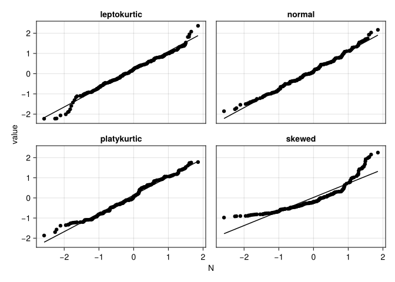

Figure 7.7: Quantile-normal plots of different random samples of $\bar{X}$ for $n=10$. The underlying popluation is either normal, short tailed (playkurtic), long tailed (leptokurtic), or skewed. For the normal and short tailed populations the distribution of $\bar{X}$ is approximately normal for this small value of $n$; for the other two populations, larger samples sizes are needed to see the aymptotic normality guaranteed by the central limit theorem.

```julia
xbar(D, n, N=200) = [mean(rand(D, n)) for _ in 1:N]
sxbar(D, n, N=200) = (xbar(D,n,N) .- mean(D)) / (std(D)/sqrt(n))

Ds = (N           = Normal(0,1),
      normal      = Normal(0,1),
      leptokurtic = TDist(3),
      skewed      = FDist(2,5),
      platykurtic = Uniform(0,1))

probs = range(0.01, 0.99, 200)
m = DataFrame([quantile.((sxbar(D,10),), probs) for D in Ds],collect(keys(Ds)))
d = stack(m, Not(:N)) # need to use QQPlot
p = data(d) * mapping(:N, :value, layout=:variable => nonnumeric) *
          (visual(QQPlot, qqline=:fit))

draw(p)
```

#### The $T$-statistic

The central limit theorem requires standardizing by the population standard deviation. At times this is neither known or assumed to be known. However, the standard error may be known:

> The *standard error* of a statistic is the standard deviation of the statistic *or* an estimate of the standard deviation.

The scaling in the central limit theorem can be redone using the standard error, $S/\sqrt{n}$:

$$T = \frac{\bar{X} - \mu}{SE(\bar{X})} = \frac{\bar{X} - \mu}{S / \sqrt{n}},$$

where $S$ is the sample standard deviation of the data set $X_1, X_2, \dots, X_n$ :

$$S = \sqrt{ \frac{1}{n-1} \sum_i^n (X_i - \bar{X_i})^2}.$$

The variability in the sampling means that the standard error will occasionally be much smaller than the population standard deviation, as this is in the denominator, the random variable $T$ will have longer tails than a standard normal. That is, the sampling distribution of $T$ should be leptokurtic, and it is:

> For a normal population, the sampling distribution of $T$ is the $T$-distribution with $n-1$ degrees of freedom.

In general, a $T$-statistic for a parameter, $\beta$, is the difference between the estimate for the parameter ($\hat{\beta}$) and the parameter, divided by the standard error of the estimator: $T = (\hat{\beta}-\beta)/SE(\hat{\beta})$. This is of the pattern “(observed - expected) / SE.”

### 7.3.2 The sample variance

For an iid random sample from a normal distribution the distribution of the sample variance $S^2$ can be identified. Consider this algebraic treatment,

$$\begin{align*}
S^2 &= \frac{1}{n-1} \sum_i^n (X_i - E(X_i))^2\\
&= \frac{\sigma^2}{n-1} \sum_i^n \left( \frac{X_i - \bar{X_i}}{\sigma} \right)^2
\end{align*}$$

If the sample is an iid random sample of normals and *were* $\bar{X_i}$ replaced by $\mu=E(X_i)$, the sum would be of $n$ iid squared standard normal which would be $Chisq(n)$ distributed. However, that isn’t quite the case. Cochran’s theorem shows for an iid random sample from a normal population the distribution of $\sum (Z_i - \bar{Z})^2$ is $Chisq(n-1)$ and $\bar{X}$ and $S^2$ are independent, which leads to:

> For an iid random sample from a normal population $(n-1) S^2/\sigma^2$ has a $Chisq(n-1)$ distribution.

#### The $F$ statistic

When there are two independent samples, there are two sample means and standard deviations. The ratio of the sample standard deviations gives insight into the question of whether the two populations have the same spread. The $F$-statistic is given by:

$$F = \frac{(S_1^2/\sigma_1^2)}{(S_2^2/\sigma_2^2)} = \frac{(\chi_{1,n_1-1}^2 / (n_1-1))}{(\chi_{2,n_2-1}^2/(n_2-1))}.$$

If the two populations are normal with means $\mu_i$ and standard deviations $\sigma_i$, then the distribution of the $F$ statistic is the $F$ distribution with $\nu_1=n_1-1$ and $\nu_2=n_2-1$ degrees of freedom.

A special case is the $T$ statistic for a normal population which has a $F(1, n-1)$ distribution owing to:

$$\begin{align*}
T^2 &= (\frac{\bar{X} - \mu}{S/\sqrt{n}})^2\\
&= \frac{(\bar{X}-\mu)^2/\sigma^2}{S^2/(n\sigma^2)}\\
&= \frac{(\bar{X}-\mu)^2/(\sigma^2/n)}{S^2/\sigma^2}\\
&= \frac{Z^2/1}{\chi^2_{n-1}/(n-1)}\\
&\sim F(1, n-1).
\end{align*}$$

That $\bar{X}$ and $S^2$ are independent under these assumptions is necessary to identify the distribution.

The distribution of the $T$ and $F$ statistics for an iid random sample is known under the assumption of a *normal* population. What if the population is not normal, how robust is the distribution of these statistics to differences in the population? This was studied in (BOX 1953). Here we show some examples through simulation.

In the following we use a long-tailed population ($T_3$) and a skewed exponential population to look:

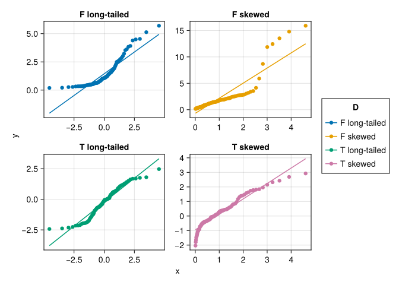

Figure 7.8: Small sample simulations of $T$ and $F$ statistic for non-normal populations. None are well described by the $T$ or $F$ distributions.

```julia
T_n(D, n) = (xs = rand(D,n); (mean(xs) - mean(D)) / (std(xs) / sqrt(n)))
F_n(D, n1, n2) = (xs = rand(D,n1); ys = rand(D, n2); (std(xs)/(n1-1)) / (std(ys)/(n2-1)))

n = 10
n1, n2 = 10, 5
N = 100


ps = range(0.01, 0.99, length=N)
SDs = (T=TDist(n-1), F=FDist(n1-1, n2-1))
Pops = (var"long-tailed"=TDist(3), skewed=Exponential(1))

# use scatter to produce qqplot
df = DataFrame([(D="$SDk $Popk", x=quantile(Popv, ps), y = quantile(rand(SDv, N), ps))
                for (SDk,SDv) in pairs(SDs) for (Popk, Popv) in pairs(Pops)])

d = data(flatten(df, [:x,:y]))
p = d * (visual(Scatter) + linear(; interval=nothing)) *
    mapping(:x, :y; layout=:D, color=:D)

draw(p, facet=(; linkxaxes=:none, linkyaxes=:none))
```

### 7.3.3 The sample median

Figure 7.9 shows through boxplots the variability of the sample median and sample mean depends on the population. For the standard normal population the ratio of the variances of $\bar{X}$ and $M$ tends to $2/\pi$. This is seen in the smaller IQR for $\bar{X}$ compared to $M$ in the figure for the normal population. This ratio isn’t always smaller than 1 for other populations.

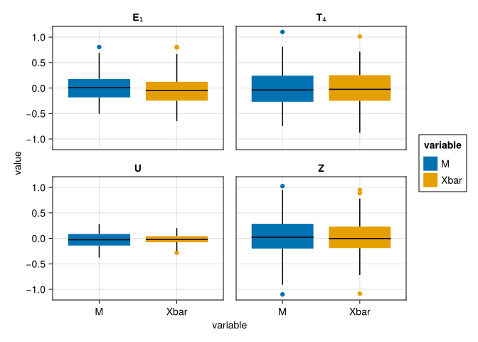

Figure 7.9: Comparison of spread of the sample median versus the sample mean for various populations. For skewed and long-tailed distributions, the sample median has smaller variability.

### 7.3.4 The Chi-squared statistic

For the multinomial distribution for a fixed $n$ with probabilities $p_1, p_2, \dots, p_k$ and counts $X_1, X_2, \dots, X_k$, the expected values are $E_i = E(X_i) = n p_i$. The difference between the observed, $X_i$, and the expected, $E_i$, are often summarized in this statistic:

$$\chi^2 = \sum_k \frac{(X_i - E_i)^2}{E_i}.$$

For this scenario, the *asymptotic* distribution of $\chi^2$ is the Chi-squared distribution with $k-1$ degrees of freedom. This number comes from the one relationship amongst the $k$ variables (that they all add up to $1$.) That is, $k-1$ $p_i$s are freely chosen, the other a dependency.

Suppose there are $s$ values, $\theta = (\theta_1, \theta_2, \dots, \theta_s)$ with some identification $f(\theta) = (p_1, p_2, \dots, p_k)$. If these $s$ values are estimated from the data (using a best asymptotically normal estimator), then there are $k - s - 1$ degrees of freedom in the asymptotic Chi-squared distribution.

The Chi-squared sampling distribution is *asymptotic* meaning for $n$ large enough. A rule of thumb is each count should be expected to be $5$ or more.

A related statistic is the Cressie-Read power-divergence statistic, (Cressie and Read 1984), parameterized by real $\lambda$ and given by:

$$2nI^\lambda = \frac{2}{\lambda(\lambda +1)} \sum_{i=1}^k X_i \left( \left(\frac{X_i}{E_i}\right)^\lambda - 1)\right).$$

When $\lambda = 1$, after some algebraic manipulations, this can be identified with the $\chi^2$ statistic above. Other values for $\lambda$ recover other named statistics, for example $\lambda=0$, for which this computes the maximum-likelihood estimate from the data. The Cressie-Read statistic also has an asymptotic $Chisq(k-s-1)$ distribution for a fixed $\lambda$.

BOX, G. E. P. (1953), “NON-NORMALITY AND TESTS ON VARIANCES,” *Biometrika*, 40, 318–335. https://doi.org/10.1093/biomet/40.3-4.318.

Cressie, N., and Read, T. R. C. (1984), “[Multinomial goodness-of-fit tests](http://www.jstor.org/stable/2345686),” *Journal of the Royal Statistical Society. Series B (Methodological)*, [Royal Statistical Society, Wiley], 46, 440–464.

[^1]: Notationally, $E(X)$ is used for the mean of a random variable, $\mu$ is used for the mean of a probability distribution, though we use them interchangeably.
[^2]: This definition of a quantile is for a continuous distribution, when the cumulative distribution is not monotonic, then definition may be the infimum over all $a$ for which $p \leq P(X \leq a)$.